# bayesian_sleepstudy_analysis

Umut Can Vural

2026-10-11

## Purpose

This document demonstrates a complete workflow for Bayesian multilevel analysis of sleepstudy data in R using brms, with prior specification, posterior inference, and model diagnostics.

## Required packages

- **tidyverse:** Tools for importing, transforming, summarising, and visualising data.
- **knitr:** Executes R Markdown code chunks and formats tables and output.
- **brms:** Specifies Bayesian regression and multilevel models using an R formula interface.
- **rstan:** Interfaces with Stan to compile models and sample from posterior distributions.
- **loo:** Estimates out-of-sample predictive performance using approximate leave-one-out cross-validation.
- **bayesplot:** Visualises posterior draws, sampling diagnostics, and posterior predictive checks.
- **lme4:** Provides the sleepstudy dataset and fits frequentist mixed-effects models for comparison.
- **tidybayes:** Tools for working with Bayesian models in a tidy workflow.

```r
library(brms)
library(rstan)
library(tidyverse)
library(bayesplot)
library(loo)
library(knitr)
library(lme4)
library(tidybayes)
```

## 01 The sleepstudy warm-up

> How does RT change over days of sleep deprivation, and how much do participants differ in their baseline RT and rate of change?

We first fit a random-intercept model to establish the workflow, then extend it to include participant-specific slopes.

```r
data("sleepstudy", package = "lme4")
glimpse(sleepstudy)
```

```
## Rows: 180
## Columns: 3
## $ Reaction <dbl> 249.5600, 258.7047, 250.8006, 321.4398, 356.8519, 414.6901, 3…
## $ Days     <dbl> 0, 1, 2, 3, 4, 5, 6, 7, 8, 9, 0, 1, 2, 3, 4, 5, 6, 7, 8, 9, 0…
## $ Subject  <fct> 308, 308, 308, 308, 308, 308, 308, 308, 308, 308, 309, 309, 3…
```

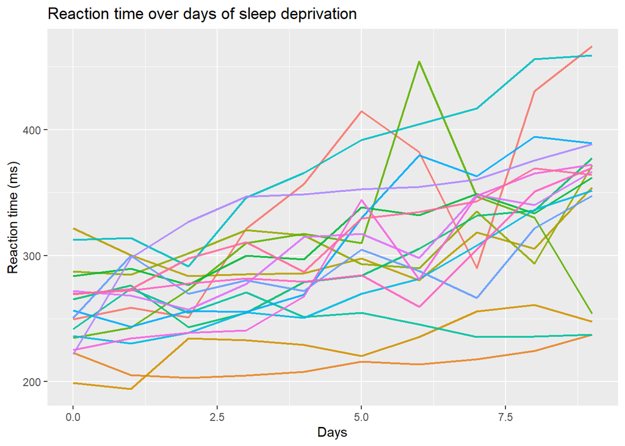

```r
# Look at the data first: one line per person
ggplot(sleepstudy, aes(Days, Reaction, group = Subject, colour = Subject)) +
  geom_line(alpha = 0.9, linewidth = 0.8) +
  labs(title = "Reaction time over days of sleep deprivation",
       x = "Days", y = "Reaction time (ms)") +
  theme(legend.position = "none")
```

Notes:

- We have repeated observations within participants therefore we need a multilevel mixed effects model.
- Given the prior assumptions and the observed data, the posterior model provides a probability distribution for the daily increase.
- Prior is not Truth. It is what seemed plausible before seeing this dataset.
- Do not mix Bayesian and frequentist interpretations. The posterior is a probability distribution over the parameter values, not a confidence interval.
- Priors can influence conclusions, especially when data are limited.
- Broadness is a design decision, justify it with domain knowledge Q: Does prior shows scientifically plausible dataset?
- MCMC: Rhat asks whether the chains found the same posterior; ESS asks how much independent information the correlated samples contain; Neff ratio expresses that information as a proportion of total draws

### Prior specification

```r
# a collection of prior specifications
priors_ri <- c(
  # Expected RT at the mean value of Days is centered at 300 ms,
  # with prior SD 100 ms.
  prior(normal(300, 100), class = Intercept), # Set the prior for the average level
  # Before observing data, how much could reaction time change per day?
  # Usually near 0 but ±20 ms or so is plausible.
  prior(normal(0, 10), class = b, coef = Days), # Set the prior for the slope of Days
  # How much might participants differ?
  # Could be substantial, but extremely huge values are less likely.
  prior(student_t(3, 0, 50), class = sd), # Set the prior for the standard deviation of the random intercepts
  # How noisy is reaction time measurement?
  # Moderate uncertainty but not infinite uncertainty.
  prior(student_t(3, 0, 50), class = sigma)# Set the prior for the residual standard deviation
)
```

> Before letting the observed RT update our parameters, what RT measurements do our priors predict?

The prior predictive check uses the model structure and priors, but **does not update** the parameters using the observed RTs. It therefore shows what kinds of datasets the current priors consider plausible before learning from the data.

```r
m_prior_ri <- brms::brm(
  Reaction ~ Days + (1 | Subject),
  data = sleepstudy,
  family = gaussian(),
  prior = priors_ri,
  sample_prior = "only", # do not update the priors with the observed data
  backend = "rstan",
  iter = 2000,
  warmup = 1000,
  chains = 4,
  cores = 2,
  seed = 2026
)
```

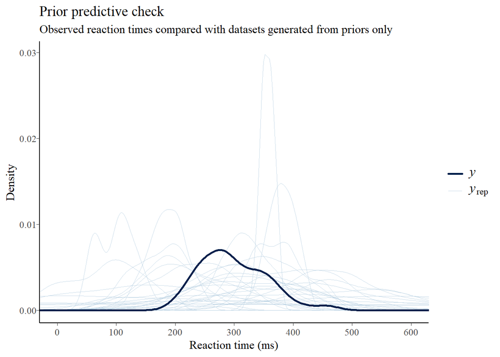

```r
pp_check(m_prior_ri, ndraws = 30) +
  coord_cartesian(xlim = c(0, 600)) +
  scale_x_continuous(breaks = seq(0, 600, by = 100))  +
  labs(
    title = "Prior predictive check",
    subtitle = "Observed reaction times compared with datasets generated from priors only",
    x = "Reaction time (ms)",
    y = "Density"
  ) +
  bayesplot::yaxis_text(TRUE) +
  bayesplot::yaxis_ticks(TRUE)
```

The summary below describes the prior distributions, not estimates updated by the observed Rts.

```r
summary(m_prior_ri)
```

```
##  Family: gaussian
##   Links: mu = identity
## Formula: Reaction ~ Days + (1 | Subject)
##    Data: sleepstudy (Number of observations: 180)
##   Draws: 4 chains, each with iter = 2000; warmup = 1000; thin = 1;
##          total post-warmup draws = 4000
##
## Multilevel Hyperparameters:
## ~Subject (Number of levels: 18)
##               Estimate Est.Error l-95% CI u-95% CI Rhat Bulk_ESS Tail_ESS
## sd(Intercept)    56.24     71.96     1.45   220.15 1.00     6848     2706
##
## Regression Coefficients:
##           Estimate Est.Error l-95% CI u-95% CI Rhat Bulk_ESS Tail_ESS
## Intercept   298.95    109.97    84.15   511.56 1.00     8142     2615
## Days          0.05      9.76   -19.28    19.74 1.00     9618     2752
##
## Further Distributional Parameters:
##       Estimate Est.Error l-95% CI u-95% CI Rhat Bulk_ESS Tail_ESS
## sigma    54.98     61.80     1.28   213.38 1.00     5682     1997
##
## Draws were sampled using sampling(NUTS). For each parameter, Bulk_ESS
## and Tail_ESS are effective sample size measures, and Rhat is the potential
## scale reduction factor on split chains (at convergence, Rhat = 1).
```

### Random intercept model

> How much does RT change per day, while accounting for participants having different starting RTs?

Reaction ij=β 0+u 0i+β 1Days ij+ϵ ij

```r
# the fitted model object
m_brms_ri <- brms::brm(
  Reaction ~ Days + (1 | Subject), # Participants have different baseline RT,
                                   # but the same underlying daily change.
  data = sleepstudy,
  family = gaussian(), # Assume normally distributed variation around each expected RT.
  prior = priors_ri,
  backend = "rstan",
  iter = 8000,   # Total iterations per chain, including warm-up
  warmup = 2000, # Sampler adaptation; learn the shape of the posterior distribution,
                 # exclude these draws from the final posterior.
  chains = 4,    # Four independent MCMC sampling chains targeting the same posterior
  cores = 2,     # Run up to two chains in parallel
  seed = 2026,   # Reproducible random seed
  save_pars = save_pars(all = TRUE)
)
```

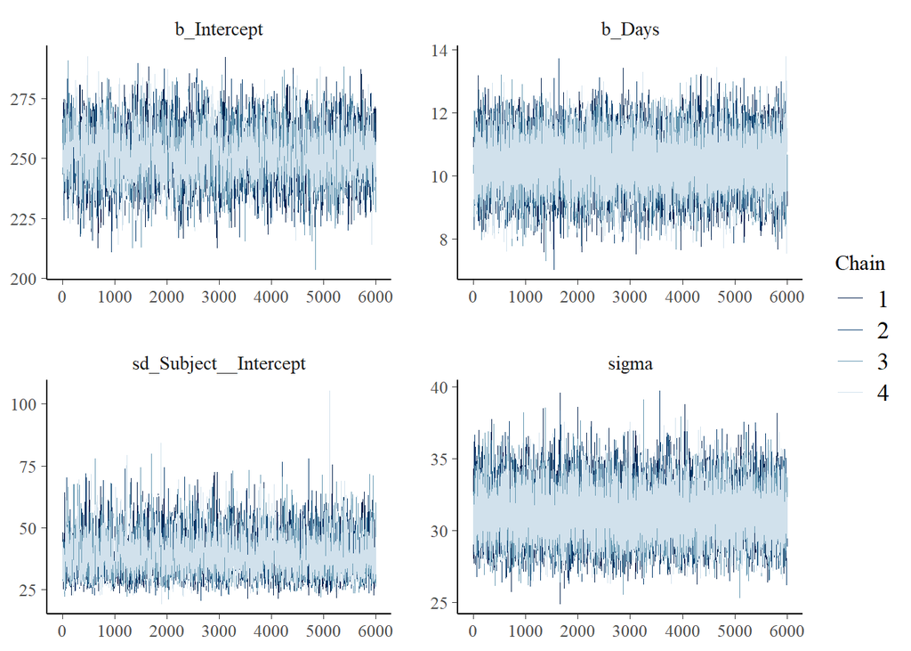

```r
mcmc_plot(m_brms_ri, type = "trace")
```

```r
neff_ratio(m_brms_ri)
```

```
##              b_Intercept                   b_Days    sd_Subject__Intercept
##                0.1334976                0.7365818                0.1892447
##                    sigma                Intercept r_Subject[308,Intercept]
##                0.7254925                0.1188025                0.2327758
## r_Subject[309,Intercept] r_Subject[310,Intercept] r_Subject[330,Intercept]
##                0.2075876                0.2317015                0.2066694
## r_Subject[331,Intercept] r_Subject[332,Intercept] r_Subject[333,Intercept]
##                0.2212187                0.2226580                0.2240262
## r_Subject[334,Intercept] r_Subject[335,Intercept] r_Subject[337,Intercept]
##                0.2161106                0.2278560                0.2169126
## r_Subject[349,Intercept] r_Subject[350,Intercept] r_Subject[351,Intercept]
##                0.2195794                0.2080605                0.2104431
## r_Subject[352,Intercept] r_Subject[369,Intercept] r_Subject[370,Intercept]
##                0.2243858                0.2055561                0.2121948
## r_Subject[371,Intercept] r_Subject[372,Intercept]                   lprior
##                0.2161766                0.2163632                0.2528436
##                     lp__                 z_1[1,1]                 z_1[1,2]
##                0.1917361                0.2206103                0.2092594
##                 z_1[1,3]                 z_1[1,4]                 z_1[1,5]
##                0.2172131                0.2129499                0.2287500
##                 z_1[1,6]                 z_1[1,7]                 z_1[1,8]
##                0.2290664                0.2257101                0.2301293
##                 z_1[1,9]                z_1[1,10]                z_1[1,11]
##                0.2186124                0.1977035                0.2258247
##                z_1[1,12]                z_1[1,13]                z_1[1,14]
##                0.2131038                0.2191616                0.2151104
##                z_1[1,15]                z_1[1,16]                z_1[1,17]
##                0.2172957                0.2251496                0.2233509
##                z_1[1,18]
##                0.2192160
```

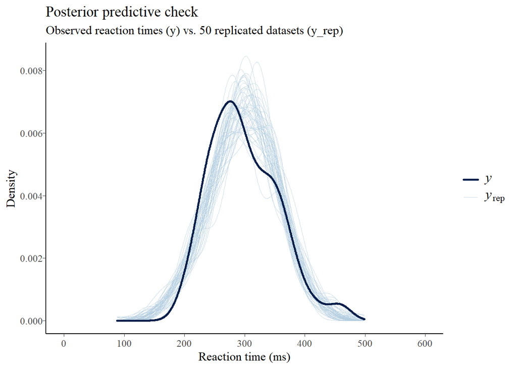

```r
#plot(m_brms_ri)

# Posterior predictive check: does the model reproduce the observed data?
pp_check(m_brms_ri, ndraws = 50) +
  coord_cartesian(xlim = c(0, 600)) +
  scale_x_continuous(breaks = seq(0, 600, by = 100))  +
  labs(
    title = "Posterior predictive check",
    subtitle = "Observed reaction times (y) vs. 50 replicated datasets (y_rep)",
    x = "Reaction time (ms)",
    y = "Density"
  ) +
  bayesplot::yaxis_text(TRUE) + # bayesplot hides the y-axis numbers by default
  bayesplot::yaxis_ticks(TRUE)
```

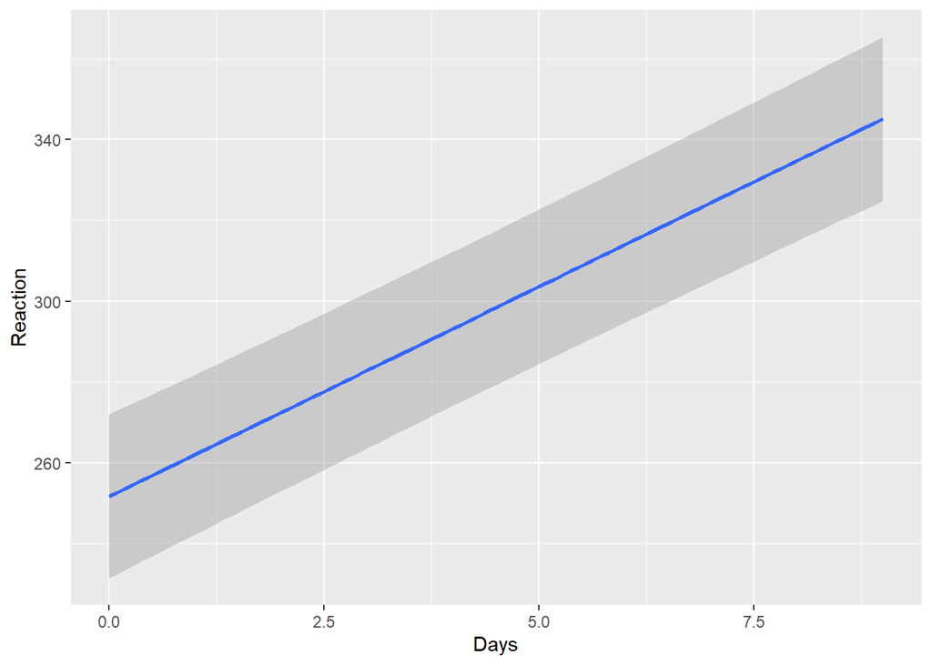

```r
conditional_effects(m_brms_ri, effects = "Days")
```

```r
summary(m_brms_ri)
```

```
##  Family: gaussian
##   Links: mu = identity
## Formula: Reaction ~ Days + (1 | Subject)
##    Data: sleepstudy (Number of observations: 180)
##   Draws: 4 chains, each with iter = 8000; warmup = 2000; thin = 1;
##          total post-warmup draws = 24000
##
## Multilevel Hyperparameters:
## ~Subject (Number of levels: 18)
##               Estimate Est.Error l-95% CI u-95% CI Rhat Bulk_ESS Tail_ESS
## sd(Intercept)    39.04      7.39    27.38    56.02 1.00     4542     7331
##
## Regression Coefficients:
##           Estimate Est.Error l-95% CI u-95% CI Rhat Bulk_ESS Tail_ESS
## Intercept   251.69     10.31   231.44   272.03 1.00     3204     5958
## Days         10.39      0.81     8.82    11.96 1.00    21437    17678
##
## Further Distributional Parameters:
##       Estimate Est.Error l-95% CI u-95% CI Rhat Bulk_ESS Tail_ESS
## sigma    31.21      1.75    28.00    34.90 1.00    19099    17412
##
## Draws were sampled using sampling(NUTS). For each parameter, Bulk_ESS
## and Tail_ESS are effective sample size measures, and Rhat is the potential
## scale reduction factor on split chains (at convergence, Rhat = 1).
```

Daily effect: RT increases by **10.40 ms per day; 95% CrI 8.82–11.99.** The interval excludes zero, so the data provide clear evidence for a positive daily effect.

Between-person variability: **sd(Intercept) = 39.16 ms**; participants differ substantially in baseline RT.

Residual variation: **sigma = 31.22 ms**; daily average reaction times varied around each participant’s fitted trajectory.

Under the random-intercept model, the population-average expected RT increased by approximately **10.40 ms** per day of sleep deprivation **(95% CrI: 8.82–11.99)**. Participants differed substantially in baseline RT (posterior median SD: **39.16 ms**), and residual day-to-day variability was approximately **31.22 ms**. The model assumes a common daily slope across participants.

The `pp_check()` function generates a probability density plot of the observed and replicated data. y: the estimated density of your observed 180 RTs. yrep: the estimated density of one replicated dataset generated from the fitted model.

The posterior predictive check compares the observed RT density (black, y) with densities from 50 datasets simulated by the fitted model (blue, yrep). Broad overlap indicates that the model reproduces the overall RT distribution, although it does not by itself establish that participant-specific trajectories are well captured.

MCMC diagnostics indicated adequate convergence: Rhat values were **1.00–1.01** and trace plots showed acceptable chain mixing. The daily-effect estimate had high effective sample size, whereas the intercept and participant-level random effects had lower sampling efficiency. The model was therefore refitted with additional iterations to improve precision for these parameters. (from 2000 to 8000 iterations, with 1000 to 2000 warmup)

The effective-sample-size ratios for the population and participant-specific intercepts were lower than for the daily effect and residual SD, reflecting autocorrelation between the global and participant-specific intercepts. Because the model used 24,000 post-warmup draws, the absolute effective sample sizes remained adequate for stable posterior estimates.

> If I become more skeptical about large slopes, what happens?

```r
# Same priors as before, except for the Days slope
priors_tighter <- c(
  set_prior("normal(300, 100)", class = "Intercept"),
  set_prior("normal(0, 2)", class = "b", coef = "Days"), # concentrated prior
  set_prior("student_t(3, 0, 50)", class = "sd"),
  set_prior("student_t(3, 0, 50)", class = "sigma")
)
```

```r
m_ri_tighter <- update(
  m_brms_ri,
  prior = priors_tighter,
  seed = 2026
)
```

```r
# Compare the Days posterior
fixef(m_brms_ri)["Days", ]
```

```
##   Estimate  Est.Error       Q2.5      Q97.5
## 10.3874611  0.8060352  8.8246143 11.9570285
```

```r
fixef(m_ri_tighter)["Days", ]
```

```
##   Estimate  Est.Error       Q2.5      Q97.5
##  8.9603718  0.7717281  7.4323692 10.4737513
```

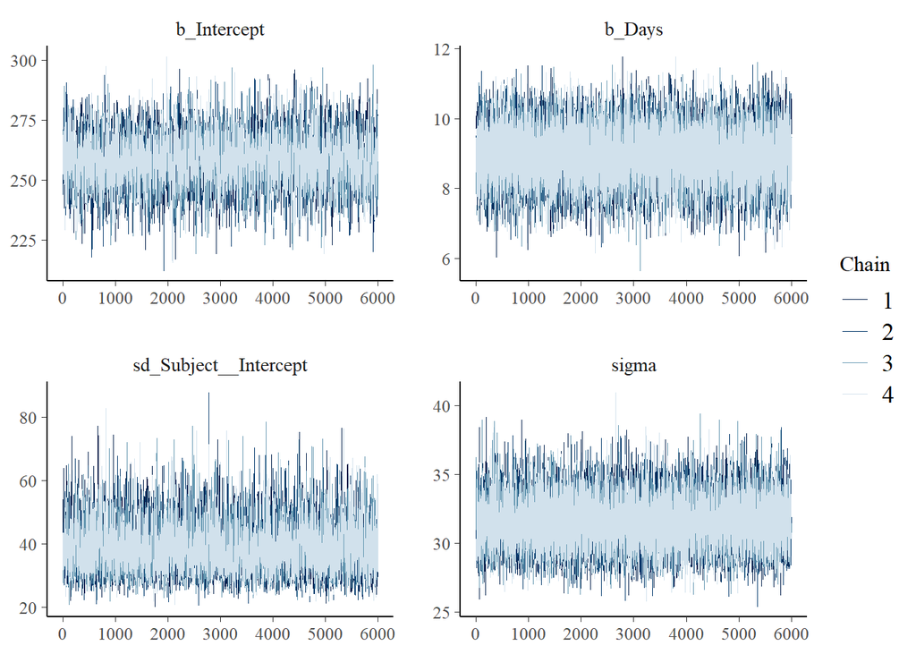

```r
mcmc_plot(m_ri_tighter, type = "trace")
```

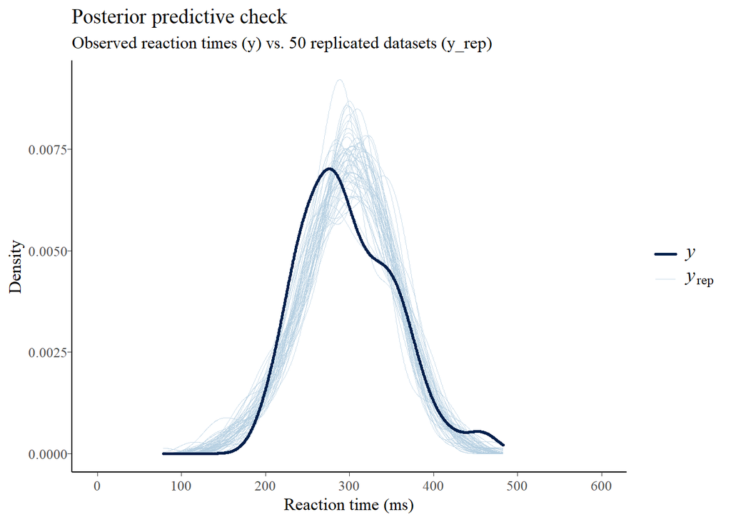

```r
pp_check(m_ri_tighter, ndraws = 50) +
  coord_cartesian(xlim = c(0, 600)) +
  scale_x_continuous(breaks = seq(0, 600, by = 100))  +
  labs(
    title = "Posterior predictive check",
    subtitle = "Observed reaction times (y) vs. 50 replicated datasets (y_rep)",
    x = "Reaction time (ms)",
    y = "Density"
  ) +
  bayesplot::yaxis_text(TRUE) + # bayesplot hides the y-axis numbers by default
  bayesplot::yaxis_ticks(TRUE)
```

```r
#neff_ratio(m_ri_tighter)
```

```r
summary(m_ri_tighter)
```

```
##  Family: gaussian
##   Links: mu = identity
## Formula: Reaction ~ Days + (1 | Subject)
##    Data: sleepstudy (Number of observations: 180)
##   Draws: 4 chains, each with iter = 8000; warmup = 2000; thin = 1;
##          total post-warmup draws = 24000
##
## Multilevel Hyperparameters:
## ~Subject (Number of levels: 18)
##               Estimate Est.Error l-95% CI u-95% CI Rhat Bulk_ESS Tail_ESS
## sd(Intercept)    39.06      7.51    27.31    56.43 1.00     4523     7271
##
## Regression Coefficients:
##           Estimate Est.Error l-95% CI u-95% CI Rhat Bulk_ESS Tail_ESS
## Intercept   258.12     10.24   238.16   278.38 1.00     3615     6525
## Days          8.96      0.77     7.43    10.47 1.00    22712    18184
##
## Further Distributional Parameters:
##       Estimate Est.Error l-95% CI u-95% CI Rhat Bulk_ESS Tail_ESS
## sigma    31.55      1.80    28.28    35.27 1.00    21654    17859
##
## Draws were sampled using sampling(NUTS). For each parameter, Bulk_ESS
## and Tail_ESS are effective sample size measures, and Rhat is the potential
## scale reduction factor on split chains (at convergence, Rhat = 1).
```

Under the primary weakly informative prior, RT increased by about **10.40** ms/day **(95% CrI: 8.82–11.99)**. Under a much tighter zero-centred prior **(SD = 2)**, the estimate fell to **8.97 ms/day (95% CrI: 7.43–10.48)**. The direction and conclusion were unchanged, but the estimate moved toward the prior, so the result is somewhat sensitive to a strongly sceptical slope prior.

The posterior predictive distributions broadly overlapped the observed RT distribution, indicating that the random-intercept model adequately reproduced the overall distribution of observed RTs.

### Random slope model

> Do participants differ not only in baseline RT, but also in how strongly sleep deprivation affects them?

Reaction ij=β 0 +u 0i +(β  +u 1i)Days ij+ϵ ij

```r
priors_rs <- c(
  prior(normal(300, 100), class = Intercept),
  prior(normal(0, 10), class = b, coef = Days),
  prior(student_t(3, 0, 50), class = sd),
  prior(student_t(3, 0, 50), class = sigma),
  prior(lkj(2), class = cor)
)
```

```r
m_brms_rs <- brms::brm(
  Reaction ~ Days + (Days | Subject),
  data = sleepstudy,
  family = gaussian(),
  prior = priors_rs,
  backend = "rstan",
  iter = 8000,
  warmup = 2000,
  chains = 4,
  cores = 2,
  seed = 2026,
  control = list(adapt_delta = 0.99),
  save_pars = save_pars(all = TRUE)
)
```

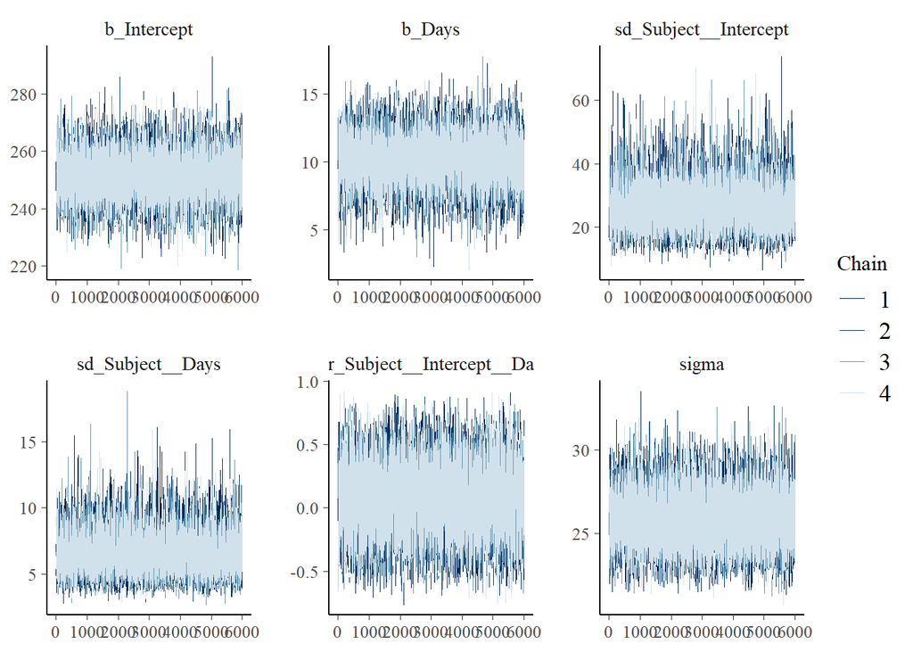

```r
mcmc_plot(m_brms_rs, type = "trace")
```

```r
neff_ratio(m_brms_rs)
```

```
##                  b_Intercept                       b_Days
##                    0.5232512                    0.4188151
##        sd_Subject__Intercept             sd_Subject__Days
##                    0.4526758                    0.3894252
## cor_Subject__Intercept__Days                        sigma
##                    0.3124621                    0.7546581
##                    Intercept     r_Subject[308,Intercept]
##                    0.3934710                    0.7656456
##     r_Subject[309,Intercept]     r_Subject[310,Intercept]
##                    0.7978057                    0.8008696
##     r_Subject[330,Intercept]     r_Subject[331,Intercept]
##                    0.7539646                    0.7917527
##     r_Subject[332,Intercept]     r_Subject[333,Intercept]
##                    0.7859895                    0.7801213
##     r_Subject[334,Intercept]     r_Subject[335,Intercept]
##                    0.7657437                    0.7731133
##     r_Subject[337,Intercept]     r_Subject[349,Intercept]
##                    0.8251062                    0.7617327
##     r_Subject[350,Intercept]     r_Subject[351,Intercept]
##                    0.8057874                    0.8302848
##     r_Subject[352,Intercept]     r_Subject[369,Intercept]
##                    0.7990574                    0.8156199
##     r_Subject[370,Intercept]     r_Subject[371,Intercept]
##                    0.7601335                    0.7909803
##     r_Subject[372,Intercept]          r_Subject[308,Days]
##                    0.7463923                    0.6495271
##          r_Subject[309,Days]          r_Subject[310,Days]
##                    0.7962757                    0.7606556
##          r_Subject[330,Days]          r_Subject[331,Days]
##                    0.6849848                    0.7133121
##          r_Subject[332,Days]          r_Subject[333,Days]
##                    0.7490975                    0.7097622
##          r_Subject[334,Days]          r_Subject[335,Days]
##                    0.7099848                    0.6861634
##          r_Subject[337,Days]          r_Subject[349,Days]
##                    0.7497418                    0.7524214
##          r_Subject[350,Days]          r_Subject[351,Days]
##                    0.6386567                    0.7027546
##          r_Subject[352,Days]          r_Subject[369,Days]
##                    0.7537168                    0.7592879
```

[output cut: 31 more lines]

```
##                    0.7347588                    0.7317314
##                    z_1[2,14]                    z_1[1,15]
##                    0.6796317                    0.7518833
##                    z_1[2,15]                    z_1[1,16]
##                    0.7323613                    0.7595264
##                    z_1[2,16]                    z_1[1,17]
##                    0.6921109                    0.7629010
##                    z_1[2,17]                    z_1[1,18]
##                    0.6792095                    0.7642865
##                    z_1[2,18]                     L_1[1,1]
##                    0.7331712                           NA
##                     L_1[2,1]                     L_1[1,2]
##                    0.3124621                           NA
##                     L_1[2,2]
##                    0.5241272
```

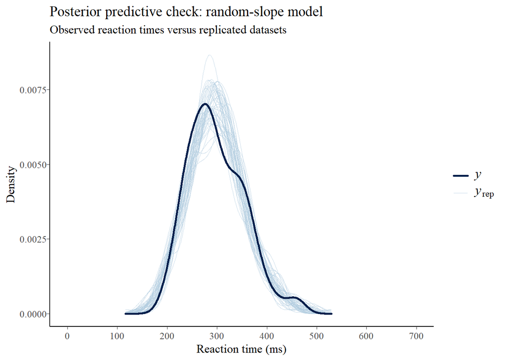

```r
#plot(m_brms_rs)

pp_check(m_brms_rs, ndraws = 50) +
  coord_cartesian(xlim = c(0, 700)) +
  scale_x_continuous(breaks = seq(0, 700, by = 100)) +
  labs(
    title = "Posterior predictive check: random-slope model",
    subtitle = "Observed reaction times versus replicated datasets",
    x = "Reaction time (ms)",
    y = "Density"
  ) +
  bayesplot::yaxis_text(TRUE) +
  bayesplot::yaxis_ticks(TRUE)
```

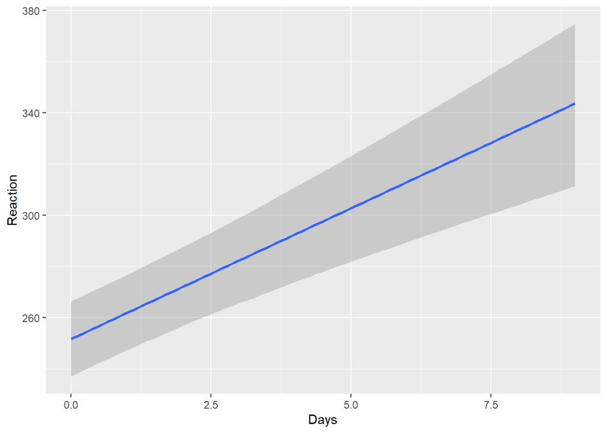

```r
conditional_effects(m_brms_rs, effects = "Days")
```

```r
summary(m_brms_rs)
```

```
##  Family: gaussian
##   Links: mu = identity
## Formula: Reaction ~ Days + (Days | Subject)
##    Data: sleepstudy (Number of observations: 180)
##   Draws: 4 chains, each with iter = 8000; warmup = 2000; thin = 1;
##          total post-warmup draws = 24000
##
## Multilevel Hyperparameters:
## ~Subject (Number of levels: 18)
##                     Estimate Est.Error l-95% CI u-95% CI Rhat Bulk_ESS Tail_ESS
## sd(Intercept)          26.67      6.76    15.46    41.85 1.00    10864    14760
## sd(Days)                6.58      1.51     4.20    10.06 1.00     9346    13695
## cor(Intercept,Days)     0.07      0.27    -0.45     0.59 1.00     7499    12044
##
## Regression Coefficients:
##           Estimate Est.Error l-95% CI u-95% CI Rhat Bulk_ESS Tail_ESS
## Intercept   251.68      7.42   237.04   266.42 1.00    12558    14362
## Days         10.20      1.68     6.80    13.43 1.00    10052    14415
##
## Further Distributional Parameters:
##       Estimate Est.Error l-95% CI u-95% CI Rhat Bulk_ESS Tail_ESS
## sigma    25.89      1.53    23.11    29.14 1.00    20137    18112
##
## Draws were sampled using sampling(NUTS). For each parameter, Bulk_ESS
## and Tail_ESS are effective sample size measures, and Rhat is the potential
## scale reduction factor on split chains (at convergence, Rhat = 1).
```

### Model comparison

```r
# leave-one-out cross-validation
loo_ri <- loo(m_brms_ri, moment_match = TRUE)
loo_rs <- loo(m_brms_rs, moment_match = TRUE)

loo_compare(loo_ri, loo_rs)
```

```
##      model elpd_diff se_diff p_worse diag_diff diag_elpd
##  m_brms_rs       0.0     0.0      NA
##  m_brms_ri     -23.2    12.1    0.97
```

The random-slope model was preferred by LOO comparison, although the difference was about **1.9 SE** and should be interpreted with some uncertainty. Substantively, the model indicated that RT increased by approximately **10.18 ms/day** on average, while the rate of increase varied across participants **(sd(Days) = 6.58, 95% CrI: 4.18–10.15)**.

Residual variation in daily average RT was approximately **25.89 ms** under the random-slope model.

The Bayesian random-slope model provided posterior distributions for participant -specific daily effects, allowing uncertainty in individual trajectories to be quantified directly. A frequentist random-slope model can also estimate participant-specific effects, but Bayesian inference provides full posterior distributions for these quantities. We can ask: What is the probability that this participant’s daily slope is greater than zero? How uncertain is each participant’s slope? How much do participant slopes vary overall?

### Predictive Check

predictive checking beyond the pooled RT distribution

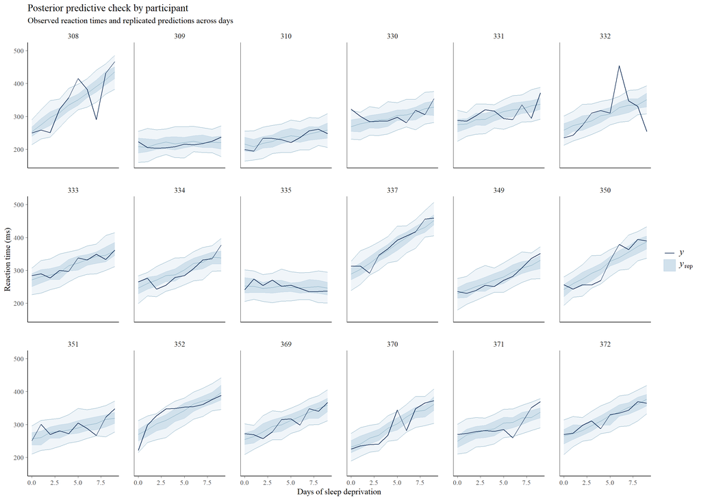

```r
pp_check(
  m_brms_rs,
  type = "ribbon_grouped",
  group = "Subject",
  x = "Days",
  ndraws = 100,
  facet_args = list(ncol = 6, scales = "fixed")
) +
  labs(
    title = "Posterior predictive check by participant",
    subtitle = "Observed reaction times and replicated predictions across days",
    x = "Days of sleep deprivation",
    y = "Reaction time (ms)"
  )
```

Most observed participant trajectories fell within the posterior predictive intervals. Some abrupt within-participant fluctuations were not captured by the linear trend, indicating local limitations of the model.

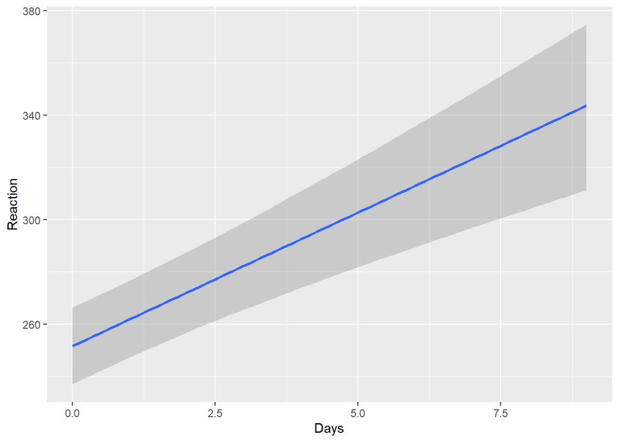

```r
# Plot participant-specific trajectories
conditional_effects(
  m_brms_rs,
  effects = "Days",
  re_formula = NA
)
```

The population-average expected RT increased from approximately **250 ms** to **350 ms** across the observed study days. The credible band widened over time because uncertainty in the daily slope accumulates.

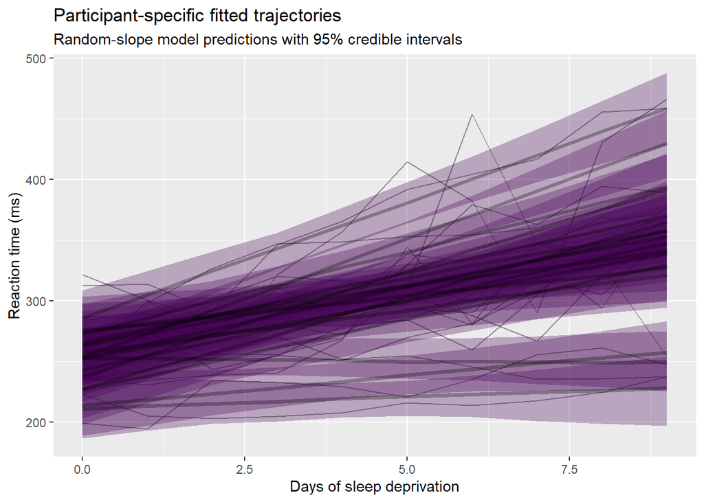

```r
sleepstudy %>%
  add_epred_draws(
    m_brms_rs,
    re_formula = NULL,
    ndraws = 100
  ) %>%
  ggplot(aes(x = Days, y = Reaction, group = Subject)) +
  geom_line(data = sleepstudy, alpha = 0.4) +
  stat_lineribbon(
    aes(y = .epred, group = Subject),
    .width = 0.95,
    alpha = 0.3
  ) +
  labs(
    title = "Participant-specific fitted trajectories",
    subtitle = "Random-slope model predictions with 95% credible intervals",
    x = "Days of sleep deprivation",
    y = "Reaction time (ms)"
  ) +
  theme(legend.position = "none")
```

Most participant-specific fitted trajectories closely followed the observed lines. The model captured the general increase in RT, while one participant with a non-linear trajectory was less well represented.

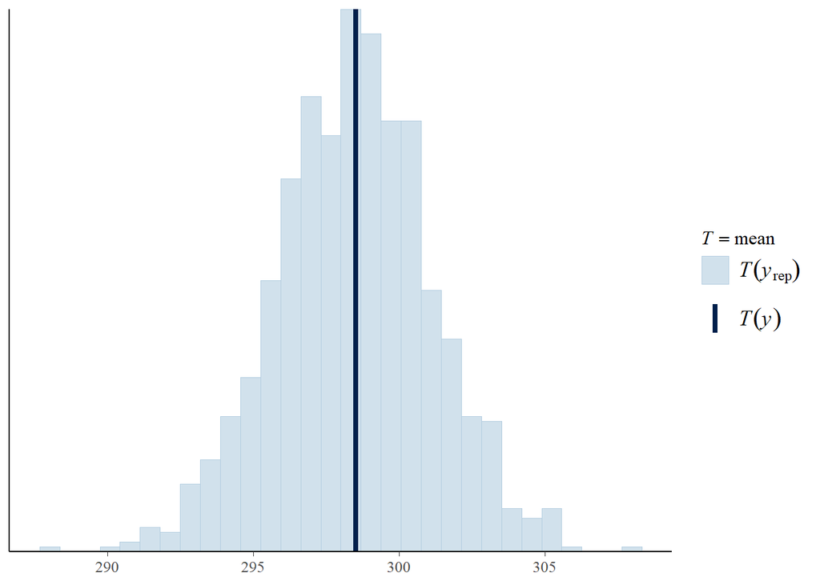

```r
#Check model fit by summary statistics

pp_check(m_brms_rs, type = "stat", stat = "mean", ndraws = 1000)
```

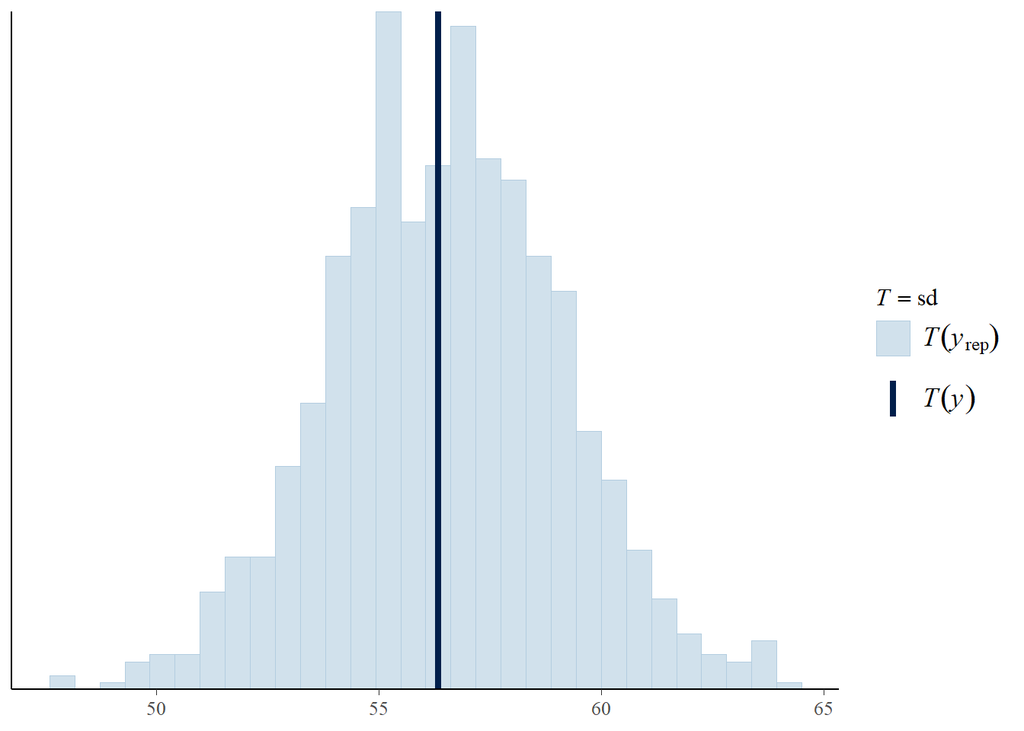

```r
pp_check(m_brms_rs, type = "stat", stat = "sd", ndraws = 1000)
```

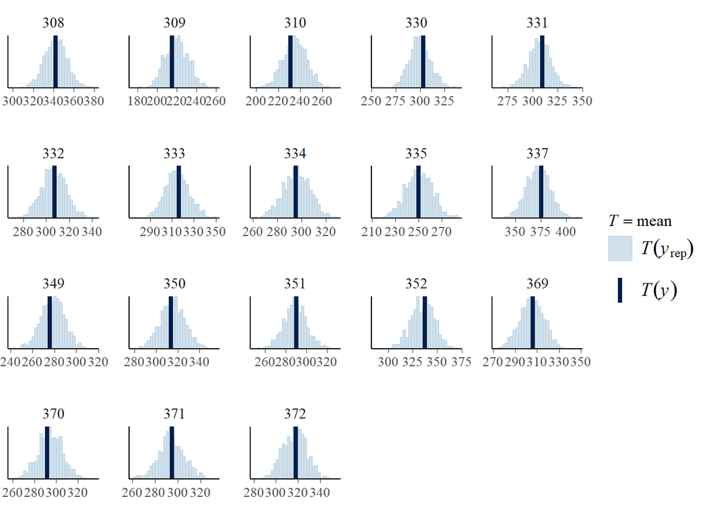

```r
pp_check(
  m_brms_rs,
  type = "stat_grouped",
  group = "Subject",
  stat = "mean",
  ndraws = 1000
)
```

Posterior predictive checks broadly reproduced the overall RT distribution and most participant trajectories. Some abrupt within-participant fluctuations were not captured by the linear trend, indicating local limitations of the model.

```r
m_freq_ri <- lme4::lmer(Reaction ~ Days + (1 | Subject), data = sleepstudy)
m_freq_rs <- lme4::lmer(Reaction ~ Days + (Days | Subject), data = sleepstudy)

freq_ri <- coef(summary(m_freq_ri))["Days", ]
freq_rs <- coef(summary(m_freq_rs))["Days", ]

bayes_ci <- function(fit) {
  d <- fixef(fit)["Days", ]
  paste0("[", round(d["Q2.5"], 2), ", ", round(d["Q97.5"], 2), "]")
}

comparison_table <- tibble(
  Model = c(
    "Bayesian random intercept",
    "Bayesian random slope",
    "Frequentist random intercept",
    "Frequentist random slope"
  ),
  `Daily effect (ms/day)` = c(
    round(fixef(m_brms_ri)["Days", "Estimate"], 2),
    round(fixef(m_brms_rs)["Days", "Estimate"], 2),
    round(freq_ri["Estimate"], 2),
    round(freq_rs["Estimate"], 2)
  ),
  Uncertainty = c(
    paste("95% CrI", bayes_ci(m_brms_ri)),
    paste("95% CrI", bayes_ci(m_brms_rs)),
    paste0("SE = ", round(freq_ri["Std. Error"], 2)),
    paste0("SE = ", round(freq_rs["Std. Error"], 2))
  )
)

knitr::kable(
  comparison_table,
  caption = "Comparison of estimated daily change in reaction time."
)
```

Comparison of estimated daily change in reaction time.

| Model | Daily effect (ms/day) | Uncertainty |
| --- | --- | --- |
| Bayesian random intercept | 10.39 | 95% CrI [8.82, 11.96] |
| Bayesian random slope | 10.20 | 95% CrI [6.8, 13.43] |
| Frequentist random intercept | 10.47 | SE = 0.8 |
| Frequentist random slope | 10.47 | SE = 1.55 |

The Bayesian random-intercept and frequentist random-intercept models produced nearly identical average daily increases in RT. The random-slope model estimated a similar population-average effect but with a wider credible interval, reflecting additional uncertainty from participant-specific daily effects. Bayesian credible intervals and frequentist standard errors should not be interpreted identically: credible intervals express posterior probability for the parameter, whereas standard errors describe sampling variability under repeated sampling.

## Results

The random-slope model was preferred by LOO comparison **(elpd_diff = −23.2, SE = 12.1, about 1.9 SEs; p_worse = 0.97)**. Substantively, RT increased by approximately **10.18 ms/day** on average, and the rate of increase varied across participants (**sd(Days) = 6.58, 95% CrI: 4.18–10.15**).

## Limitations

The analysis assumes linear change over study days, normally distributed residuals, and no remaining serial dependence after accounting for participant effects. Abrupt fluctuations in some trajectories were not fully captured. The study includes only 18 participants, limiting the precision of population-level variability estimates. Prior sensitivity was examined for the common slope in the random-intercept model, but not comprehensively for the final random-slope model.

## Author

Umut Can Vural 2026 MIT License